# Data Manipulation Part 2: Exercises

## Exercises

These exercises accompany the [Data Manipulation 2](http://rpubs.com/NateByers/datamanip2) tutorial.

1. Use the `mutate()` function to add two columns to the `chicago_air` dataset: a column named “violation” indicating when the ozone value is above 0.075 ppm and a column named “cumulative_total” that is the cumulative total of violations for the year. (*Hint: look at the `dplyr` vignette on window-functions.*)

Solution

2. Use the `gather()` function to reshape the `chicago_wind` data frame from a wide format to a long format.

Solution

3. Use the `spread()` function to turn the long data frame from exercise 2 back into a wide data frame.

Solution

4. Use the `summarize_each()` function to replace the `chicago_air` daily values with monthly maximum values.

Solution

5. Reshape the monthly data from exercise 4 to a long format and plot it using `ggplot()`.

Solution

## Solutions

### Solution 1

Here’s a good first stab at a solution.

```r
library(region5air)
library(dplyr)

data(chicago_air)
ozone_violations <- mutate(chicago_air, violation = ozone > 0.075,
                           cumulative_total = cumsum(violation))
```

But the `ozone_violations` data frame gives `NA` values in the “cumulative_total” column at day 2013-07-01. This is because there are `NA` ozone values. We can solve this by removing rows with ozone `NA`s first.

```r
ozone_violations <- filter(chicago_air, !is.na(ozone))
ozone_violations <- mutate(ozone_violations,
                           violation = ozone > 0.075,
                           cumulative_total = cumsum(violation))
head(ozone_violations, 3)
```

```
##         date ozone temp solar month weekday violation cumulative_total
## 1 2013-01-01 0.032   17  0.65     1       3     FALSE                0
## 2 2013-01-02 0.020   15  0.61     1       4     FALSE                0
## 3 2013-01-03 0.021   28  0.17     1       5     FALSE                0
```

```r
tail(ozone_violations, 3)
```

```
##           date ozone temp solar month weekday violation cumulative_total
## 337 2013-12-29 0.029   NA  0.08    12       1     FALSE                2
## 338 2013-12-30 0.024   NA  0.44    12       2     FALSE                2
## 339 2013-12-31 0.021   NA  0.49    12       3     FALSE                2
```

Back to exercises

### Solution 2

```r
library(tidyr)
data(chicago_wind)
head(chicago_wind, 3)
```

```
## Source: local data frame [3 x 4]
##
##             datetime wind_speed wind_dir ozone
##                (chr)      (dbl)    (dbl) (dbl)
## 1 20130101T0000-0600          2      334    NA
## 2 20130101T0100-0600          2      321    NA
## 3 20130101T0200-0600          2      323    NA
```

```r
long_wind <- gather(chicago_wind, key = parameter, value = value,
                    wind_speed:ozone, na.rm = TRUE)
head(long_wind, 3)
```

```
## Source: local data frame [3 x 3]
##
##             datetime  parameter value
##                (chr)     (fctr) (dbl)
## 1 20130101T0000-0600 wind_speed     2
## 2 20130101T0100-0600 wind_speed     2
## 3 20130101T0200-0600 wind_speed     2
```

Back to exercises

### Solution 3

```r
wide_wind <- spread(long_wind, key = parameter, value = value)
head(wide_wind)
```

```
## Source: local data frame [6 x 4]
##
##             datetime wind_speed wind_dir ozone
##                (chr)      (dbl)    (dbl) (dbl)
## 1 20130101T0000-0600        2.0      334    NA
## 2 20130101T0100-0600        2.0      321    NA
## 3 20130101T0200-0600        2.0      323    NA
## 4 20130101T0300-0600        1.6      324    NA
## 5 20130101T0400-0600        1.6      319    NA
## 6 20130101T0500-0600        1.4      319    NA
```

Back to exercises

### Solution 4

```r
air_monthly <- group_by(chicago_air, month)
air_monthly <- summarize_each(air_monthly, funs(max(., na.rm = TRUE)),
                              -(weekday), -(date))
air_monthly
```

```
## Source: local data frame [12 x 4]
##
##    month ozone  temp solar
##    (dbl) (dbl) (dbl) (dbl)
## 1      1 0.034    53  0.74
## 2      2 0.041    45  0.97
## 3      3 0.052    52  1.23
## 4      4 0.062    74  1.39
## 5      5 0.081    82  1.49
## 6      6 0.074    84  1.46
## 7      7 0.043    92  1.47
## 8      8 0.066    89  1.40
## 9      9 0.078    91  1.23
## 10    10 0.057    75  1.05
## 11    11 0.030    NA  0.81
## 12    12 0.030    NA  0.70
```

Back to exercises

### Solution 5

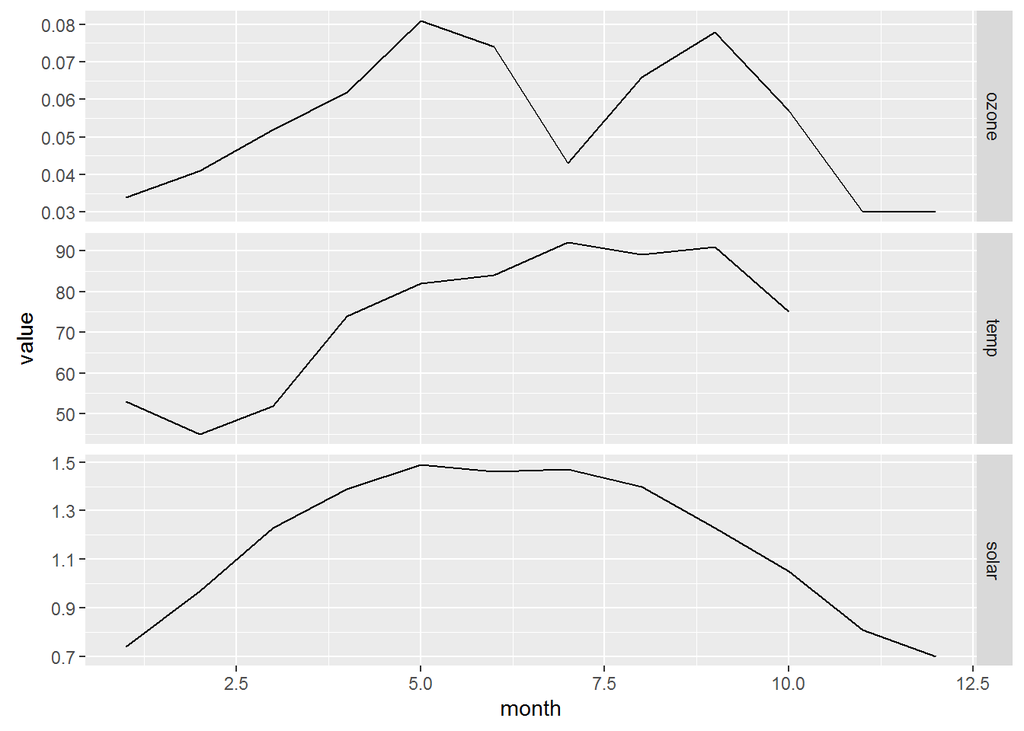

```r
air_monthly_long <- gather(air_monthly, parameter, value, ozone:solar)
library(ggplot2)
p <- ggplot(air_monthly_long, aes(month, value))
p + geom_line() + facet_grid(parameter ~., scales = "free")
```

Back to exercises